# Exploring Red Wine Quality by Chun Zhu

## About

In this exercise, I will explore the dataset of red wine quality. I’d like to find out which chemical properties influence the quality of red wines. This tidy data set contains 1,599 red wines with 11 variables on the chemical properties of the wine. At least 3 wine experts rated the quality of each wine, providing a rating between 0 (very bad) and 10 (very excellent).

## Summary of the Dataset

First let’s check some basic structure and statitics of the data set.

```
## 'data.frame':    1599 obs. of  13 variables:
##  $ X                   : int  1 2 3 4 5 6 7 8 9 10 ...
##  $ fixed.acidity       : num  7.4 7.8 7.8 11.2 7.4 7.4 7.9 7.3 7.8 7.5 ...
##  $ volatile.acidity    : num  0.7 0.88 0.76 0.28 0.7 0.66 0.6 0.65 0.58 0.5 ...
##  $ citric.acid         : num  0 0 0.04 0.56 0 0 0.06 0 0.02 0.36 ...
##  $ residual.sugar      : num  1.9 2.6 2.3 1.9 1.9 1.8 1.6 1.2 2 6.1 ...
##  $ chlorides           : num  0.076 0.098 0.092 0.075 0.076 0.075 0.069 0.065 0.073 0.071 ...
##  $ free.sulfur.dioxide : num  11 25 15 17 11 13 15 15 9 17 ...
##  $ total.sulfur.dioxide: num  34 67 54 60 34 40 59 21 18 102 ...
##  $ density             : num  0.998 0.997 0.997 0.998 0.998 ...
##  $ pH                  : num  3.51 3.2 3.26 3.16 3.51 3.51 3.3 3.39 3.36 3.35 ...
##  $ sulphates           : num  0.56 0.68 0.65 0.58 0.56 0.56 0.46 0.47 0.57 0.8 ...
##  $ alcohol             : num  9.4 9.8 9.8 9.8 9.4 9.4 9.4 10 9.5 10.5 ...
##  $ quality             : int  5 5 5 6 5 5 5 7 7 5 ...
```

```
##        X          fixed.acidity   volatile.acidity  citric.acid
##  Min.   :   1.0   Min.   : 4.60   Min.   :0.1200   Min.   :0.000
##  1st Qu.: 400.5   1st Qu.: 7.10   1st Qu.:0.3900   1st Qu.:0.090
##  Median : 800.0   Median : 7.90   Median :0.5200   Median :0.260
##  Mean   : 800.0   Mean   : 8.32   Mean   :0.5278   Mean   :0.271
##  3rd Qu.:1199.5   3rd Qu.: 9.20   3rd Qu.:0.6400   3rd Qu.:0.420
##  Max.   :1599.0   Max.   :15.90   Max.   :1.5800   Max.   :1.000
##  residual.sugar     chlorides       free.sulfur.dioxide
##  Min.   : 0.900   Min.   :0.01200   Min.   : 1.00
##  1st Qu.: 1.900   1st Qu.:0.07000   1st Qu.: 7.00
##  Median : 2.200   Median :0.07900   Median :14.00
##  Mean   : 2.539   Mean   :0.08747   Mean   :15.87
##  3rd Qu.: 2.600   3rd Qu.:0.09000   3rd Qu.:21.00
##  Max.   :15.500   Max.   :0.61100   Max.   :72.00
##  total.sulfur.dioxide    density             pH          sulphates
##  Min.   :  6.00       Min.   :0.9901   Min.   :2.740   Min.   :0.3300
##  1st Qu.: 22.00       1st Qu.:0.9956   1st Qu.:3.210   1st Qu.:0.5500
##  Median : 38.00       Median :0.9968   Median :3.310   Median :0.6200
##  Mean   : 46.47       Mean   :0.9967   Mean   :3.311   Mean   :0.6581
##  3rd Qu.: 62.00       3rd Qu.:0.9978   3rd Qu.:3.400   3rd Qu.:0.7300
##  Max.   :289.00       Max.   :1.0037   Max.   :4.010   Max.   :2.0000
##     alcohol         quality
##  Min.   : 8.40   Min.   :3.000
##  1st Qu.: 9.50   1st Qu.:5.000
##  Median :10.20   Median :6.000
##  Mean   :10.42   Mean   :5.636
##  3rd Qu.:11.10   3rd Qu.:6.000
##  Max.   :14.90   Max.   :8.000
```

## Univariate Plots Section

quality should be an ordered, categorical, discrete variable. So first I’ll add a new quality variable called quality_factor. And below shows that quality factor is an ordered variable.

```
##  Ord.factor w/ 6 levels "3"<"4"<"5"<"6"<..: 3 3 3 4 3 3 3 5 5 3 ...
```

Let’s check the distribution of all 12 variables.

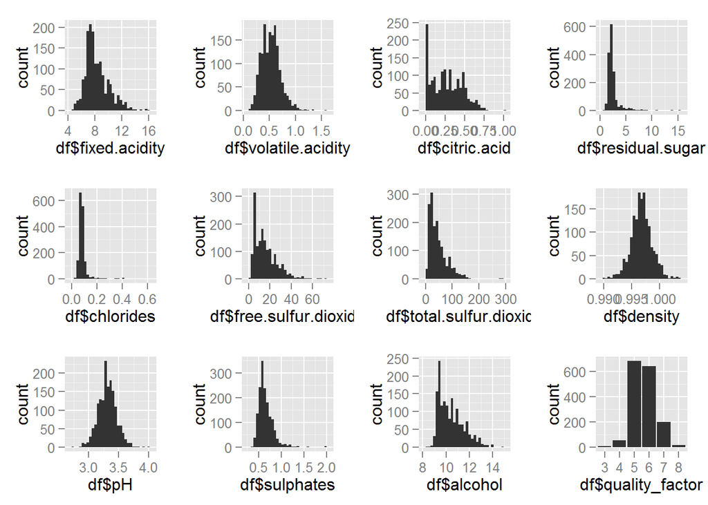

## Univariate Analysis

Wine quality interests me most. So I’ll get a better distribution plot.

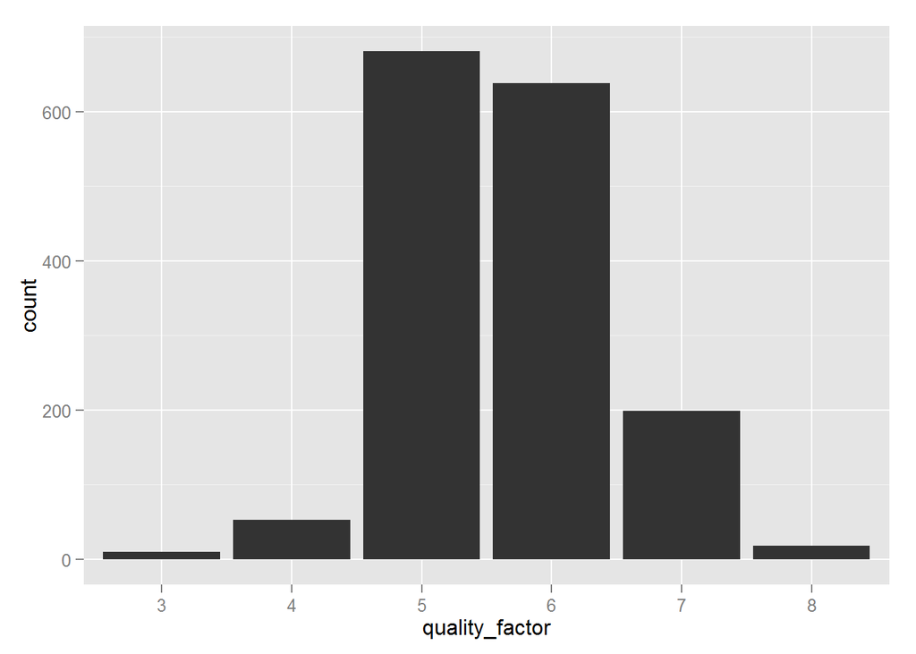

So red wine quality appears normally distributed.

For the 11 chemical features, we can clearly see that density and pH are normally distributed. fixed.acidity, volatile.acidity, sulfur.dioxide, sulphates and alcohol have long tails. residual.sugar and chlorides have a large number of outliers. So I first truncated residual.sugar and chlorides by 95th percentile.

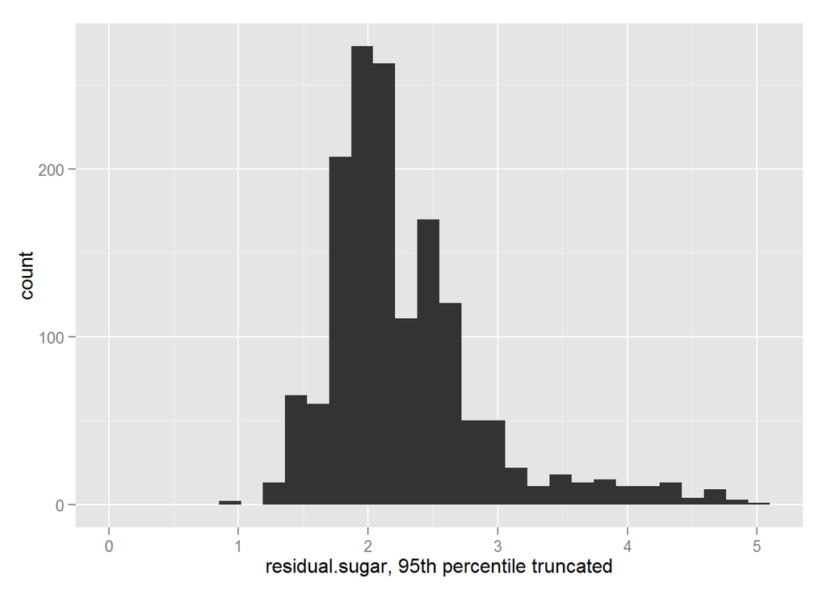

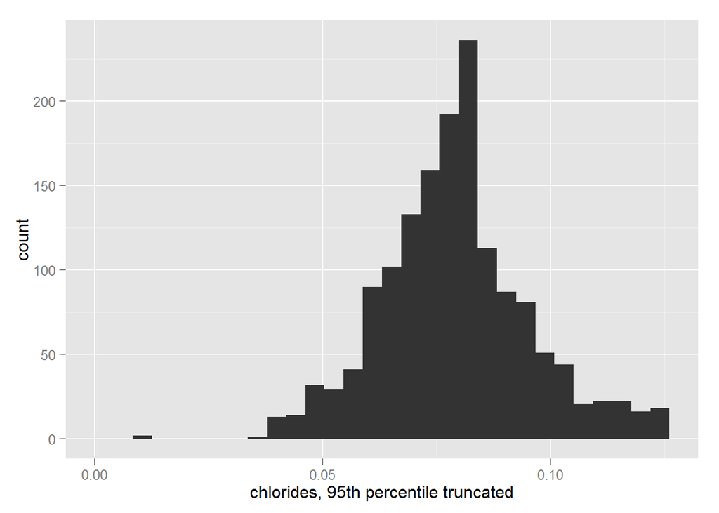

After truncating, the 2 plots look more normally distributed.

For the other features I applied base 10 logarithmic scale in the plots.

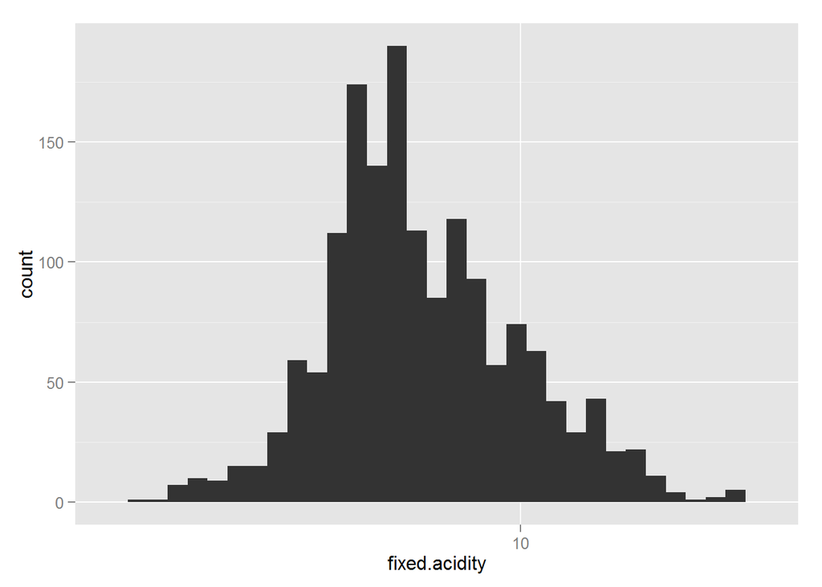

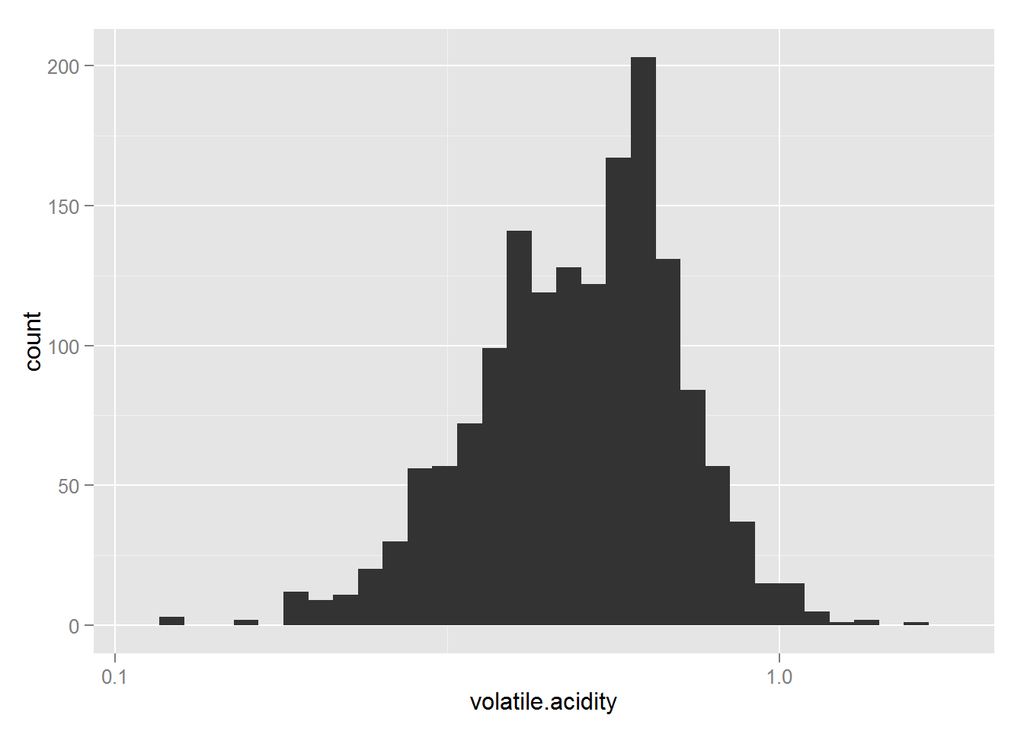

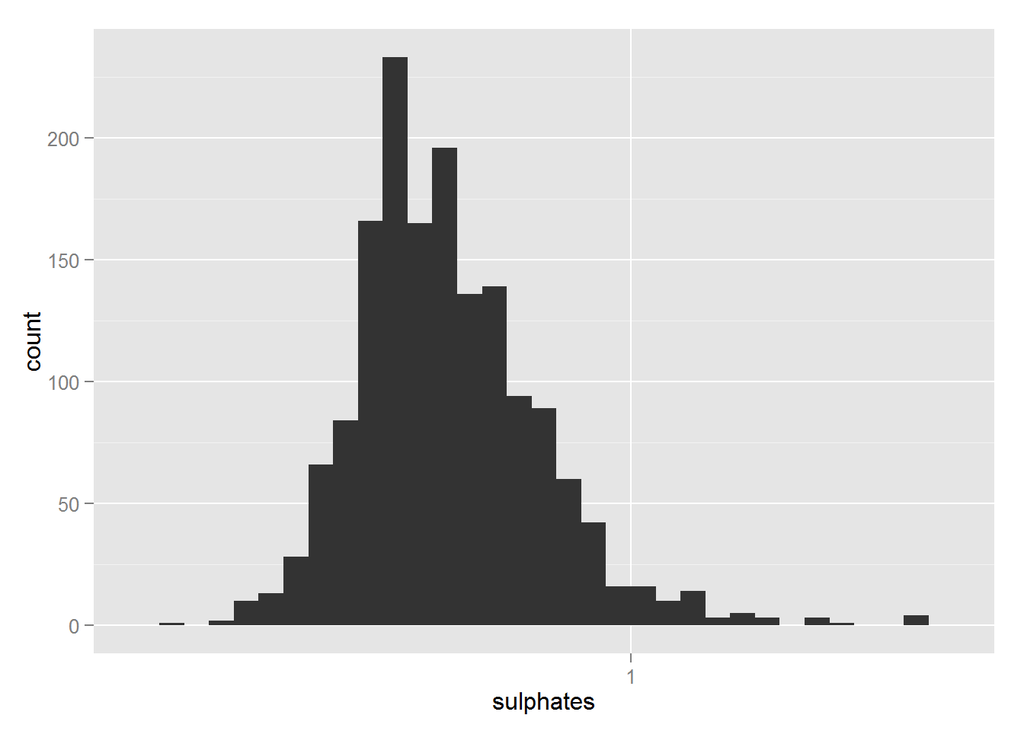

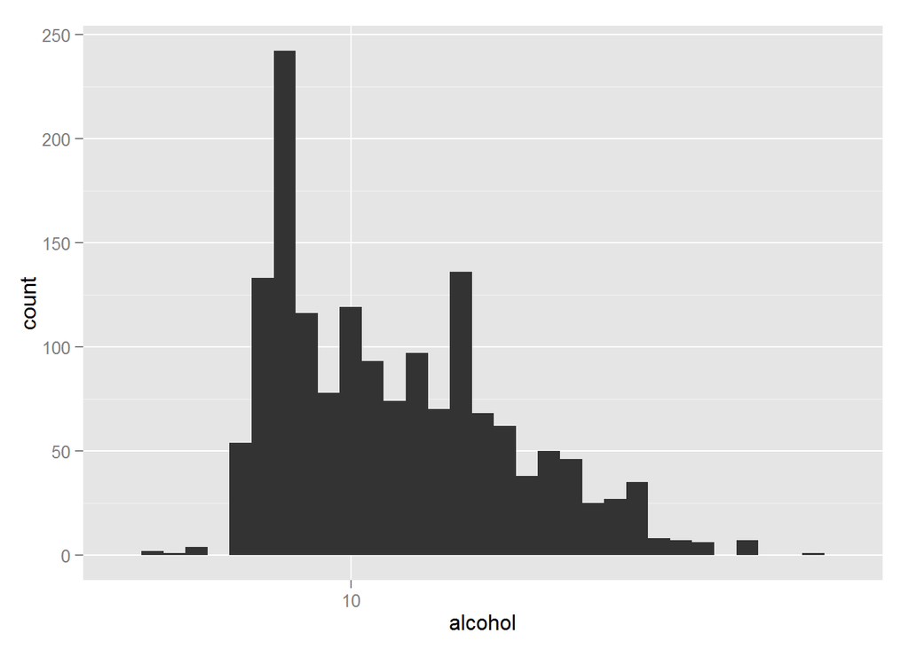

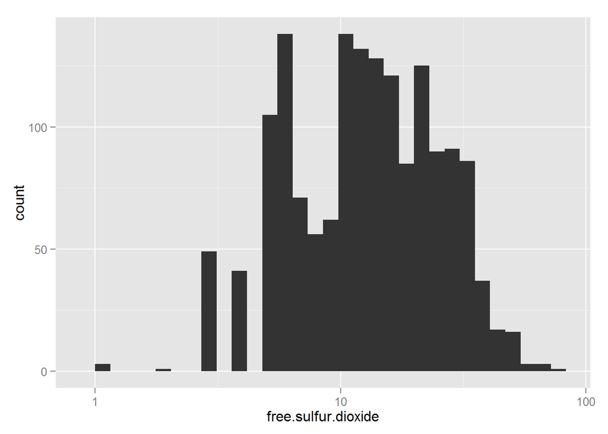

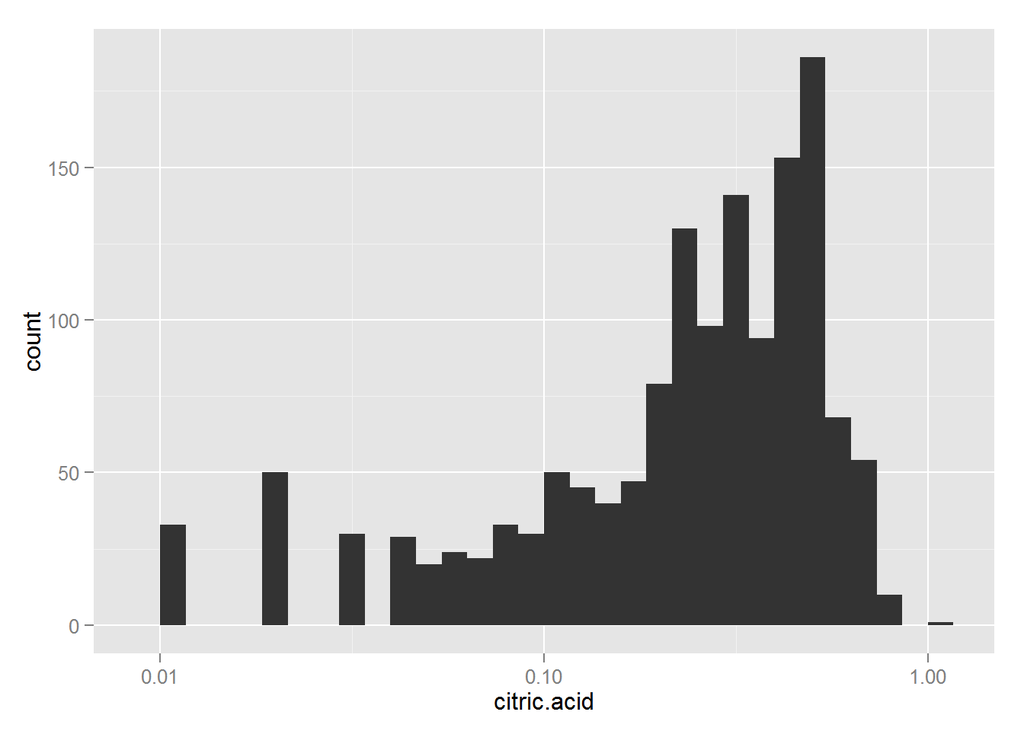

When plotted on log10 scale, fixed.acidity, volatile.acidity and sulphates look normally distributted. However, alcohol and citric.acid still look a little bit skewed. free.sulfur.dioxide look like 2 different bell in the distribution.

## Bivariate Plots and Analysis

First I’d like to investigate the correlation between any 2 variables in the data set. (note that I use log10(sulphates) in the analysis)

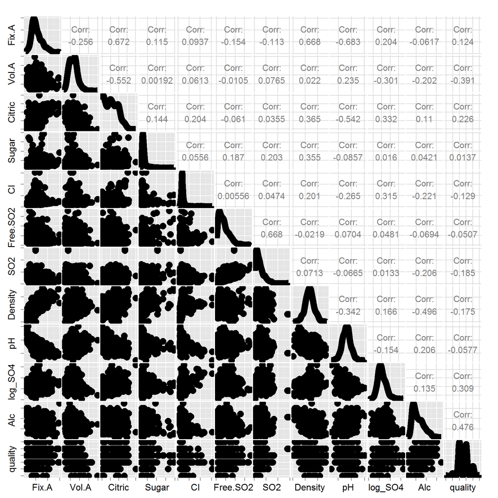

Some Observations:

- Input pairs with strong positive correlation:
  - fixed.acidity and citric.acid
  - fixed.acidity and density
  - free.sulfur.dioxide and total.sulfur.dioxide
- Input pairs with strong negative correlation:
  - fixed.acidity and pH
  - volatile.acidity and citric.acid
  - citric.acid and pH
  - density and alcohol

We need to be aware of strong correlation among input variables to avoid multicollinear effect in model builing.

Another interest topic is to find out the correlation between output variable quality and input variables.

Some findings:

- quality is strongly correlated with alcohol (~0.476)
- quality is moderately correlated with volatile.acidity (~-0.391), citric.acid (0.226) and sulphates (0.309).
- Correlation is not that strong between quality and other input variables.

Since quality is somewhat correlated with alcohol, volatile.acidity, citric.acid and sulphates from correlation study, let’s examine further the relation between quality and these 4 variables.

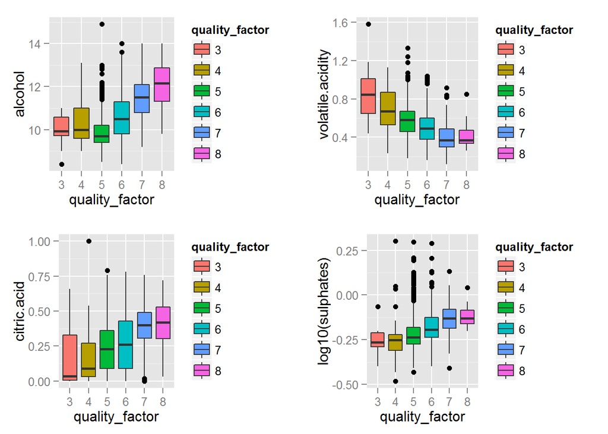

From the plot we can clearly see that wine qaulity is generally better with higher alcohol levels, citric.acid and sulphates. At the meantime, lowr volatile.acidity seems produce a higher quality.

Next I’ll examine the relationship among some strong correlated input pairs.

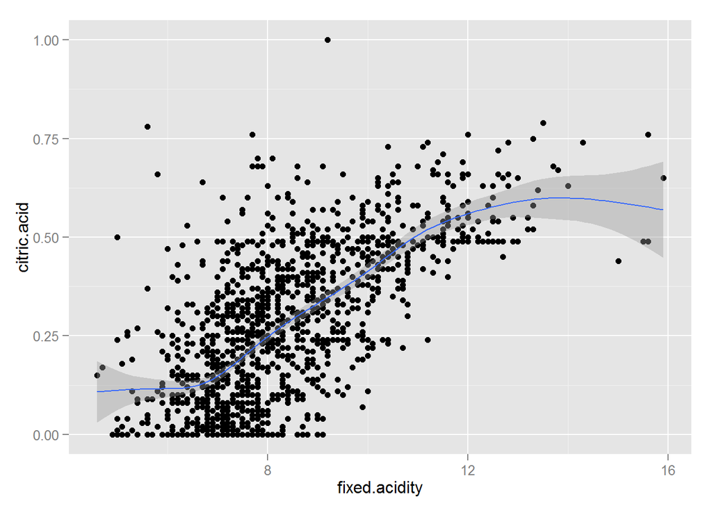

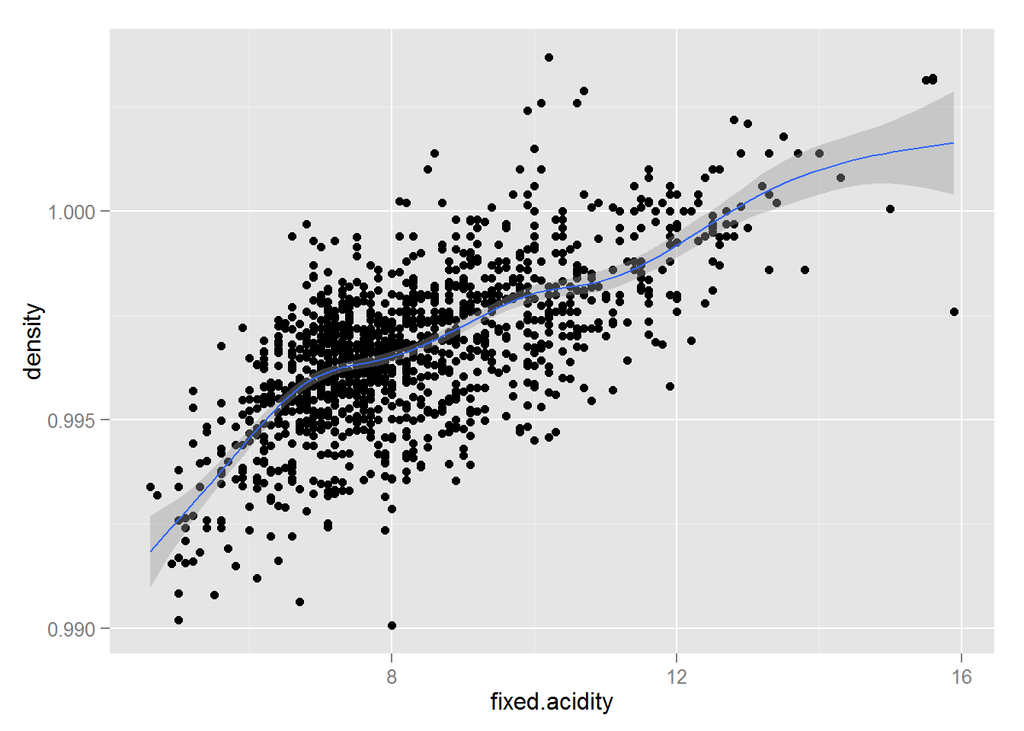

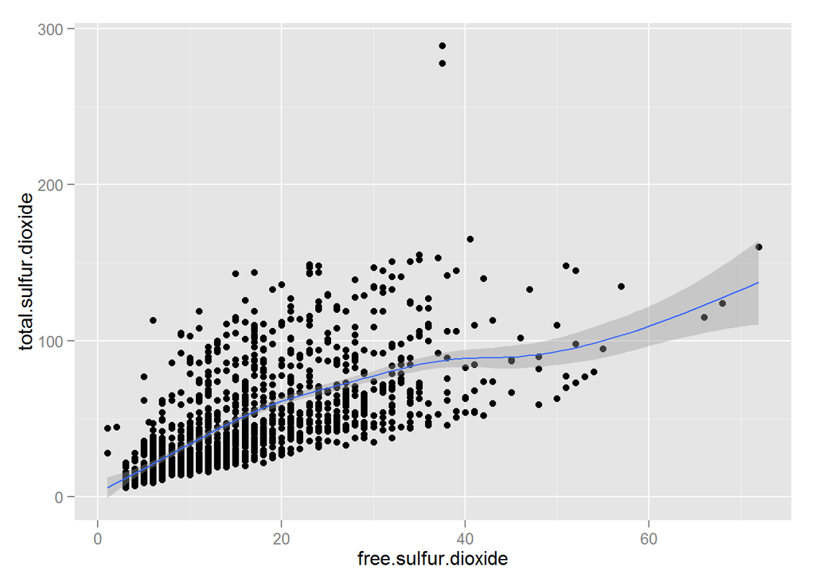

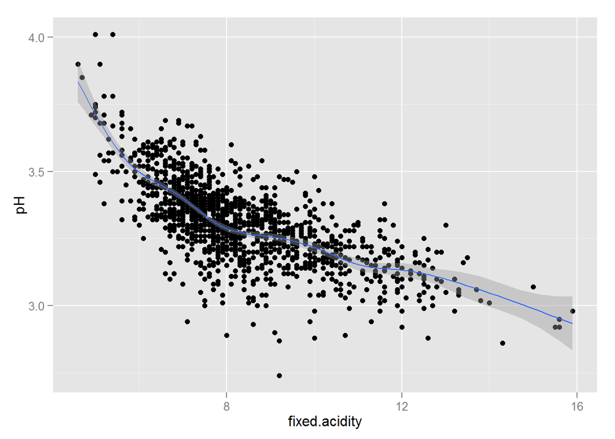

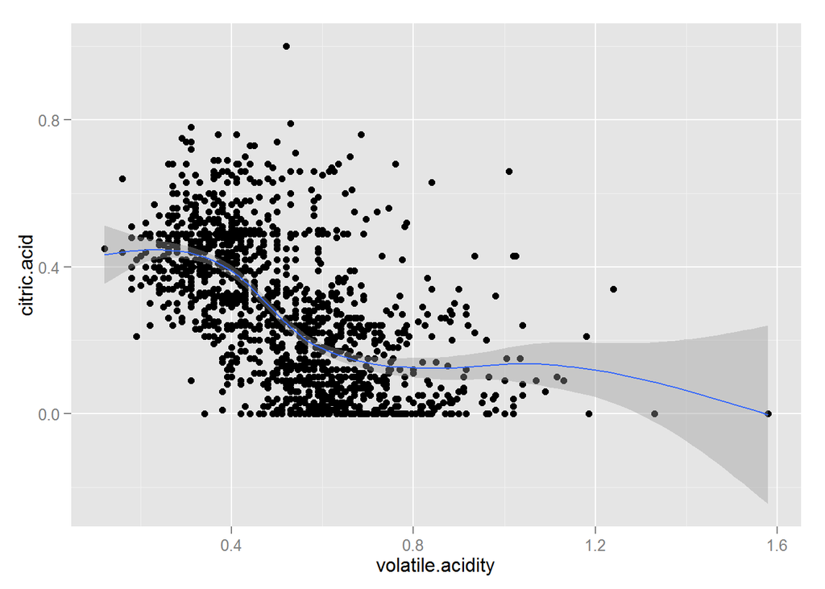

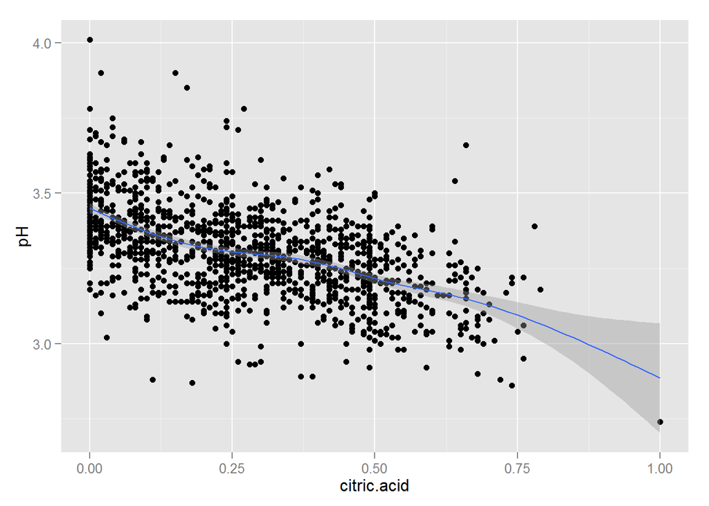

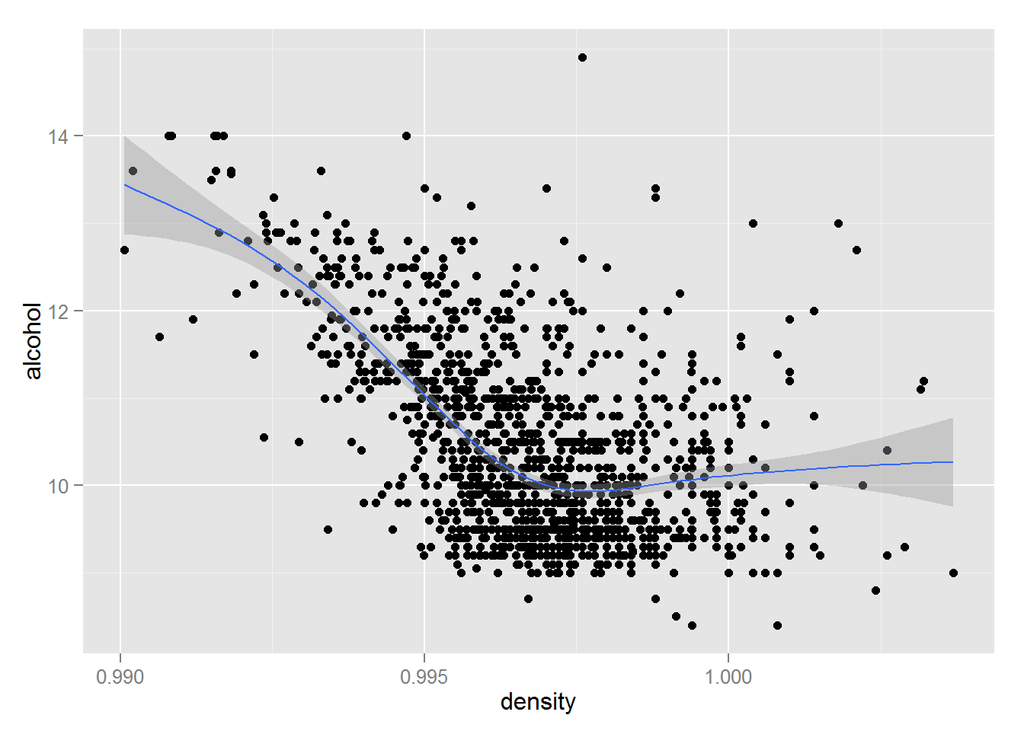

We can see strong negative correlation in pairs (fixed.acidity, pH), (volatile.acidity, citric.acid), (citric.acid, pH) and (density, alcohol).

## Multivariate Plots Section

Based on the bivariate analysis above, I am most interested in 4 variables - alcohol, volatile.acidity, citric.acid and sulphates, as these 4 variables have some correlations with wine quality.

Since quality is strongly correlated with alcohol, moderately correlated with volatile.acidity, while the correlation between alcohol and volatile.acidity is not big, I’ll first check how alcohol and volatile.acidity affect quality.

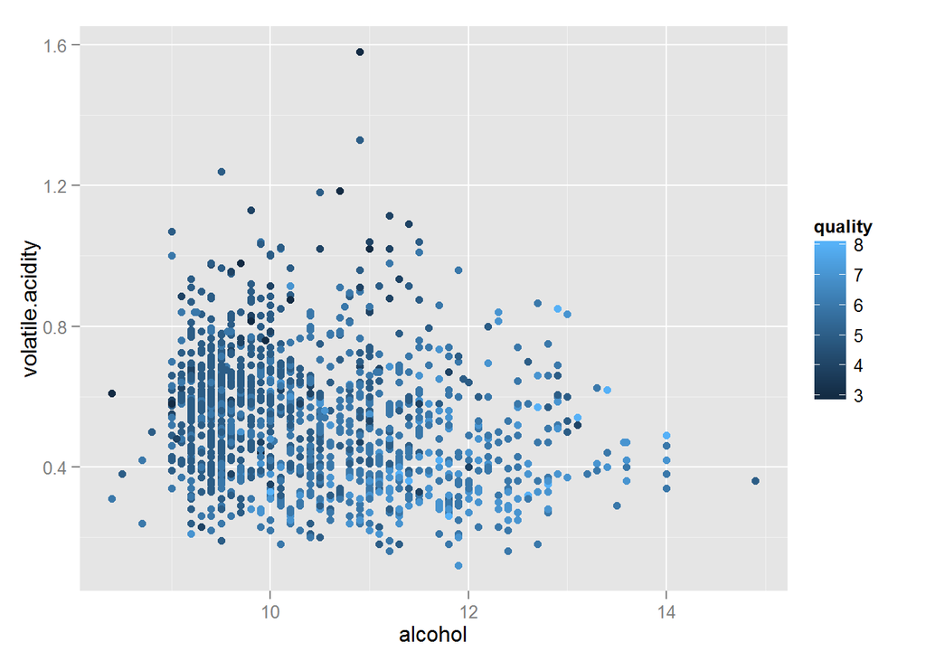

```
##     bad average    good
##      63    1319     217
```

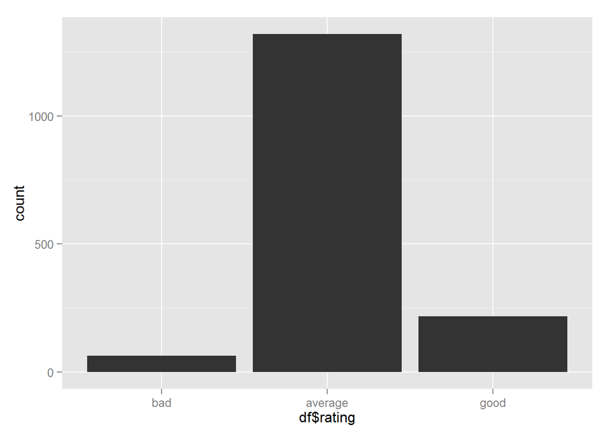

Below is the scatter plot of red wine ratings on alcohol and volatile.acidity.

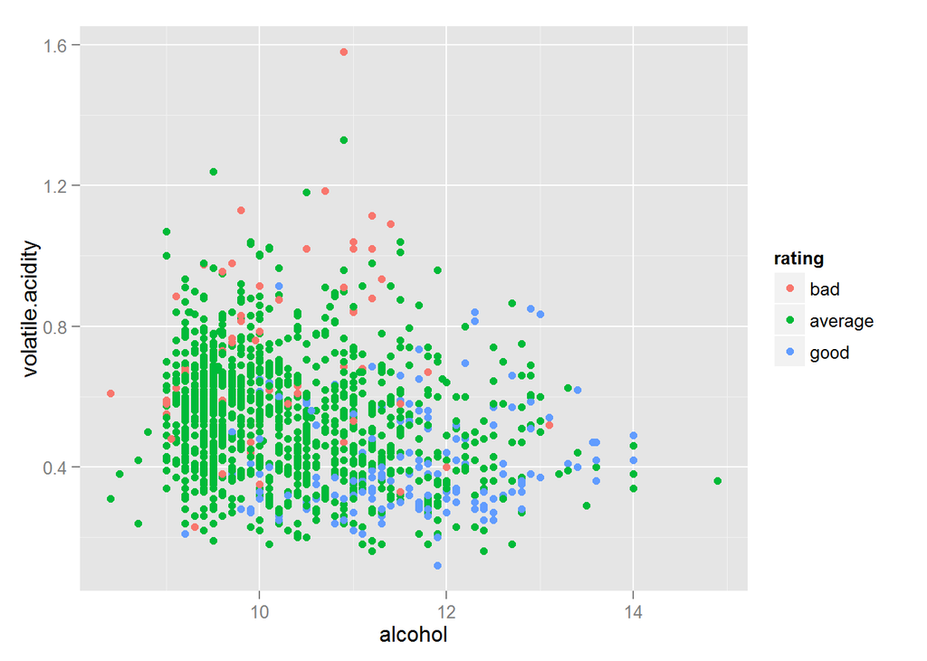

There seems to be a relationship between alcohol percentage and wine quality. To examine the relationship better, I’ll just plot ‘bad’ and ‘good’ red wine.

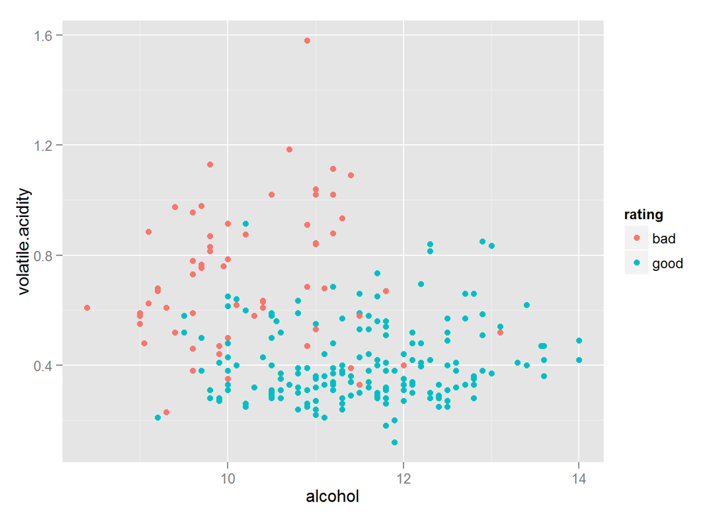

from the above graph, we can see that good wines are more likely with higher alcohol percentage and lower volatile.acidity.

Next let’s examine how alcohol and citric.acid affect ratings.

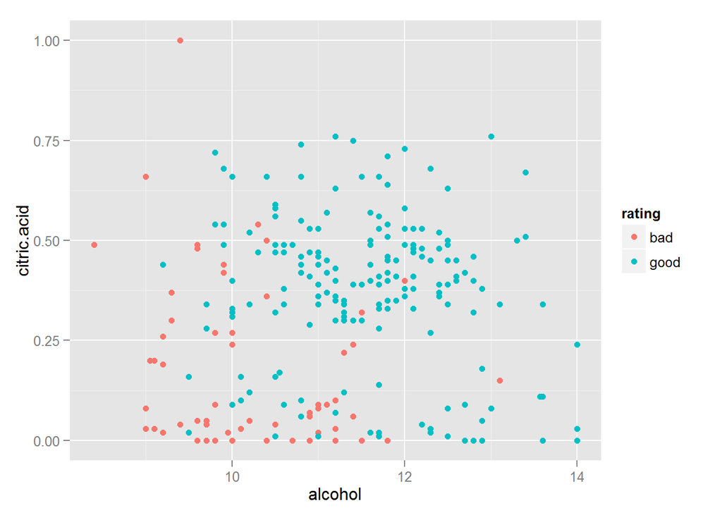

It’s clear that good wines are more likely with higher alcohol percentage and higher citric.acid. This conclusion is consistent with the correlation results.

Alcohol and sulphates plot:

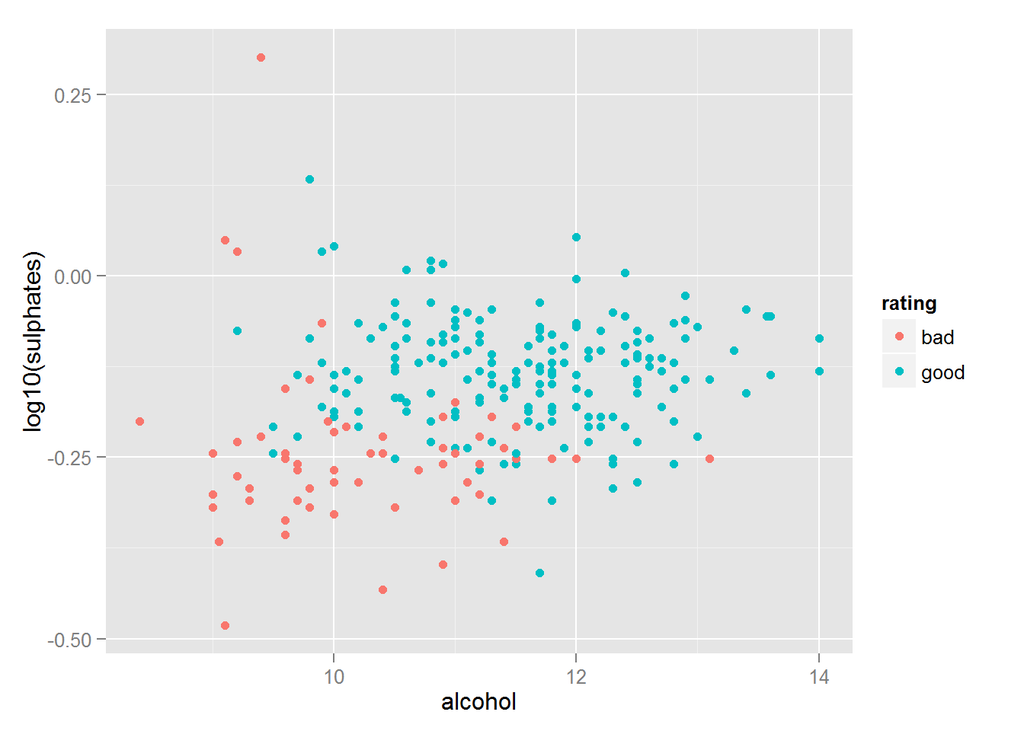

It’s clear that good wines are more likely with higher alcohol percentage and higher sulphates This conclusion is consistent with the correlation results.

volatile.acidity and citric.acid plot:

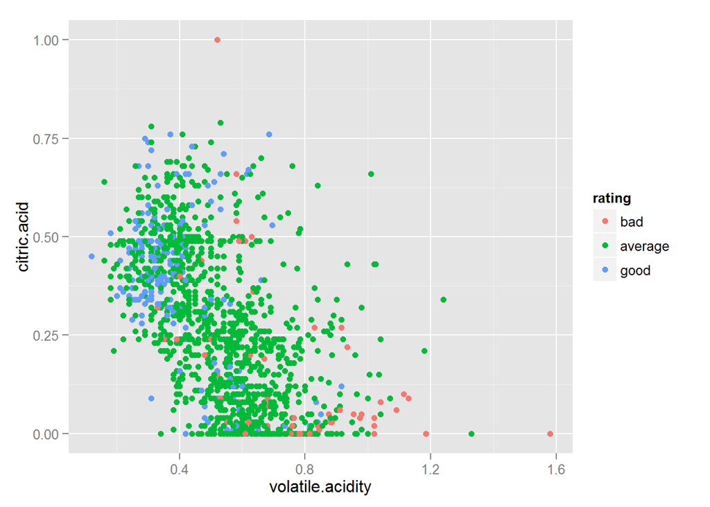

It’s clear that good wines are more likely with lower volatile.acidity and higher citric.acid. This plot also show that volatile.acidity and citric.acid have a strong negative correlation. This conclusion is consistent with the correlation results.

volatile.acidity and sulphates plot:

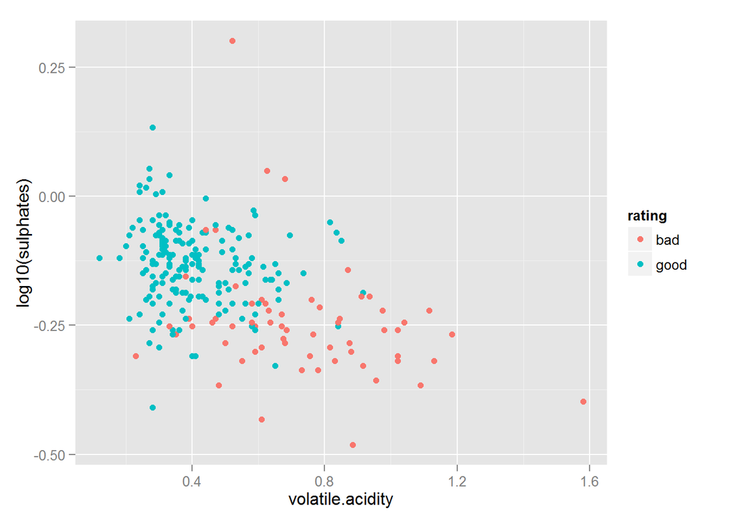

It’s clear that good wines are more likely with lower volatile.acidity and higher sulphates. This conclusion is consistent with the correlation results.

citric.acid and sulphates plot:

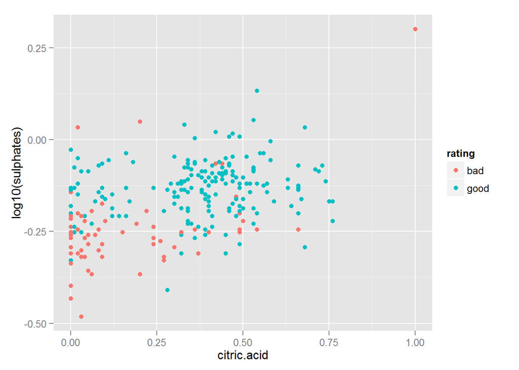

It’s clear that good wines are more likely with higher citric.acid and higher sulphates. This conclusion is consistent with the correlation results.

## Multivariate Analysis

From the above plots, we can conclude that higher alcohol, lower volatile.acidity, higher citric.acid and higher sulphates are more likely to result in better red wines.

## Final Plots and Summary

### Plot One: Histogram of Red Wine Quality

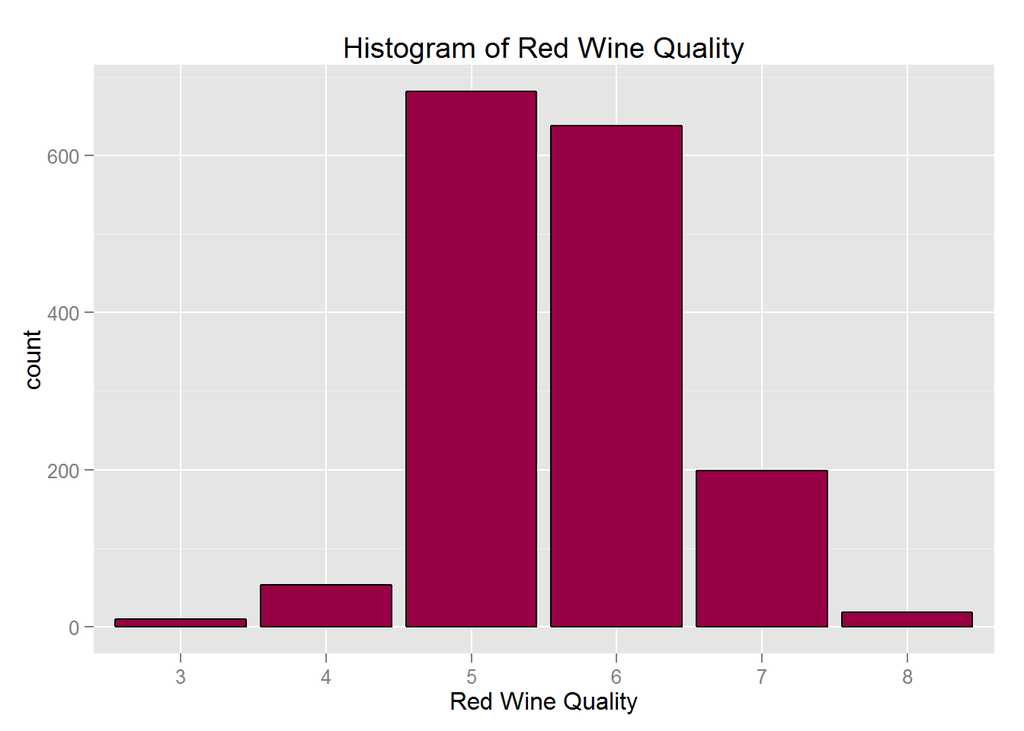

### Description One

From the literature, quality was on a 0-10 scale, and was rated by at least 3 wine experts. The values ranged only from 3 to 8, with a mean of 5.6 and median of 6.The histogram of wine quality shows that the quality generally follows normal distribution. Most red wines are rated between 5 and 6.

### Plot Two: Effect of Alcohol levels on Red Wine Quality

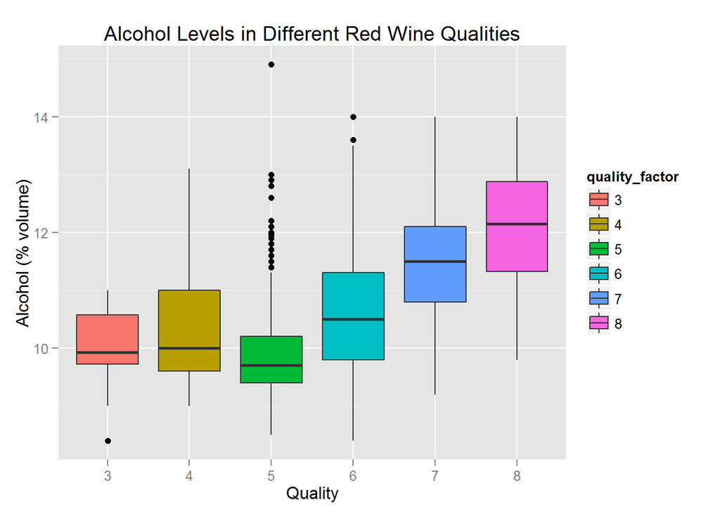

### Description Two

Alcohol level and Quality have correlation value of 0.476. This is the strongest correlation I have found between an objective wine parameter and wine quality. These boxplots clearly demonstrate that wine qaulity is generally better with higher alcohol levels. At the meantime, alcohol alone does not produce a higher quality.

### Plot Three:Features affect Red Wine Quality

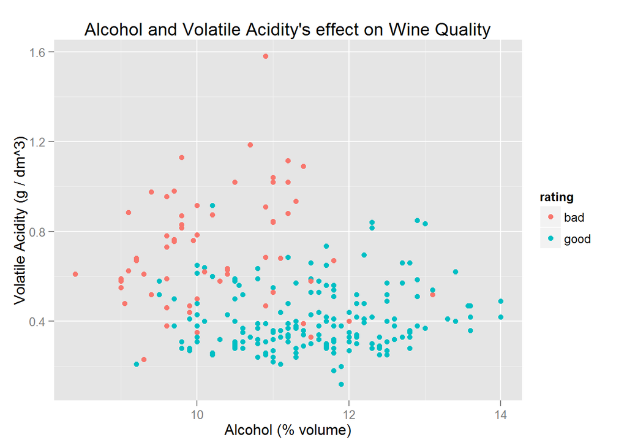

### Description Three

From the correlation study, we know that alcohol and volatile acidity have the highest correlation with quality. The correlation between alcohol and quality is 0.476, while the correlation between volatile acidity and quality is -0.391. Plot 3 clearly supports this point. To better illustrate the relationship, I subsetted the data to remove the ‘average’ wines, or any wine with a quality of 5 or 6. The above graph tells us that a combination of high alcohol levels and low volatile acidity produced better red wines.

## Reflection

From this exploratory data analysis, I was able to identity several main features which affect red wine quality: alcohol, volatile acidity and sulphates. alcohol has positive relationship with the quality of red wine while Volatile Acidity has negative one. Among them, the alcohol level is the most important factor to determine the red wine quality as it has the strongest impact on quality.

Further analysis can be done by building a model to predict red wine quality by the 2 features: alcohol and volatile acidity.